# Assignment 5: Data Visualization with ggplot2

Louis Dion

9/30/2019

#Using c2015 dataset

```r
library(tidyverse)
library(readxl)
c2015<-read_excel('C:/Users/student/Documents/MATH421/data/c2015.xlsx')
```

# 1. Clean the data for easy graphing

##Remove observations that are unknown,fix age and TRAV_SP,filter for drivers

```r
c2015<-c2015%>%mutate(TRAV_SP=sapply(strsplit(TRAV_SP,split=" ",fixed = TRUE),function(x) (x[1])), TRAV_SP=as.numeric(TRAV_SP))
c2015<-c2015%>%filter_all(~!is.na(.))
c2015<-c2015%>%filter_all(~!(.=='Unknown'))
c2015<-c2015%>%filter_all(~!(.=='Other'))
c2015<-c2015%>%filter_all(~!(.=='Unknown (Police Reported)'))
c2015<-c2015%>%filter_all(~!(.=='Injured, Severity Unknown'))
c2015<-c2015%>%filter_all(~!(.=='Not Rep'))
c2015<-c2015%>%filter_all(~!(.=='Not Reported'))
c2015<-c2015%>%filter_all(~!(.==str_detect(.,'Not Rep')))
c2015<-c2015%>%filter_all(~!(.==str_detect(.,'Unknown')))
c2015<-c2015%>%mutate(AGE=replace(AGE,AGE=='Less than 1','0'),AGE=as.numeric(AGE))
c2015<-c2015%>%filter(SEAT_POS=='Front Seat, Left Side')
```

#2.Use geom_point to plot AGE and TRAV_SP coloring by SEX.

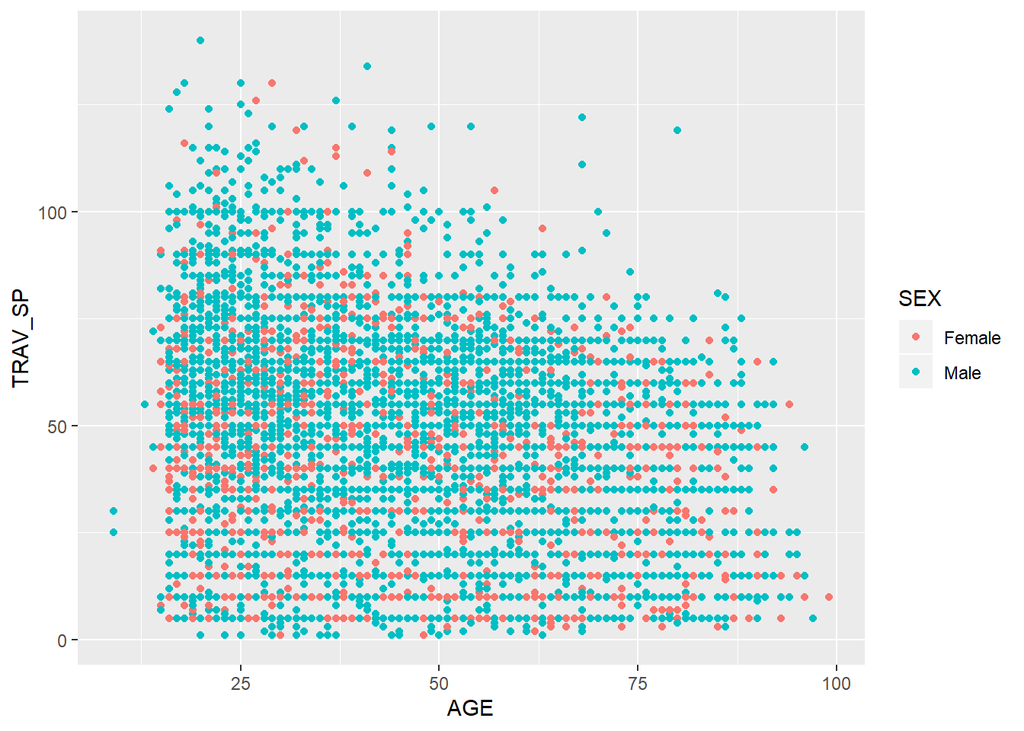

```r
ggplot(c2015,aes(AGE,TRAV_SP,col=SEX))+
  geom_point()
```

#3.There is overplotting in 2. Overplotting is when many points are duplicated on the graph. Use geom_jitter instead of geom_point for 2. to avoid overplotting.

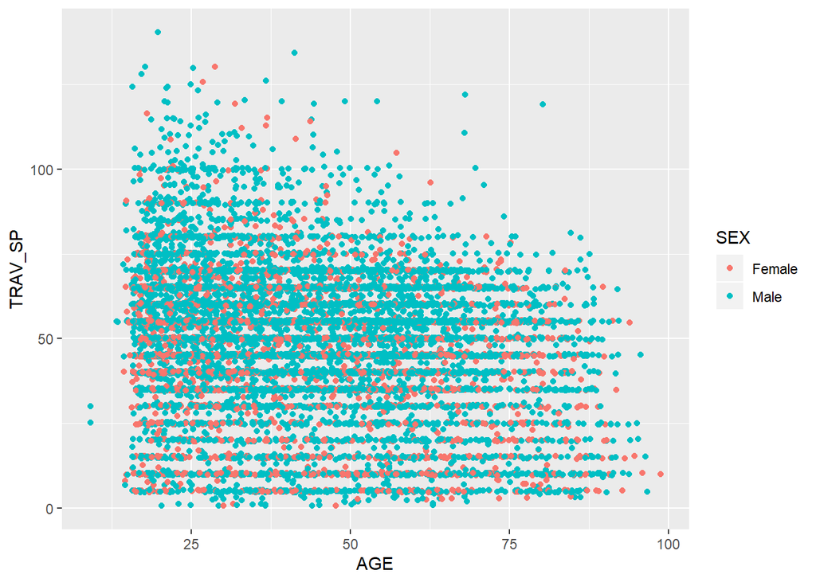

```r
ggplot(c2015,aes(AGE,TRAV_SP,col=SEX))+
  geom_jitter()
```

#4.Plot histograms of AGE, TRAV_SP with bins = 50.

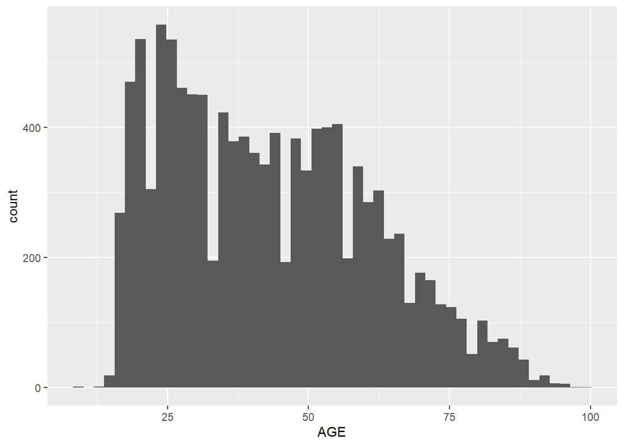

```r
ggplot(c2015,aes(x=AGE))+
  geom_histogram(bins=50)
```

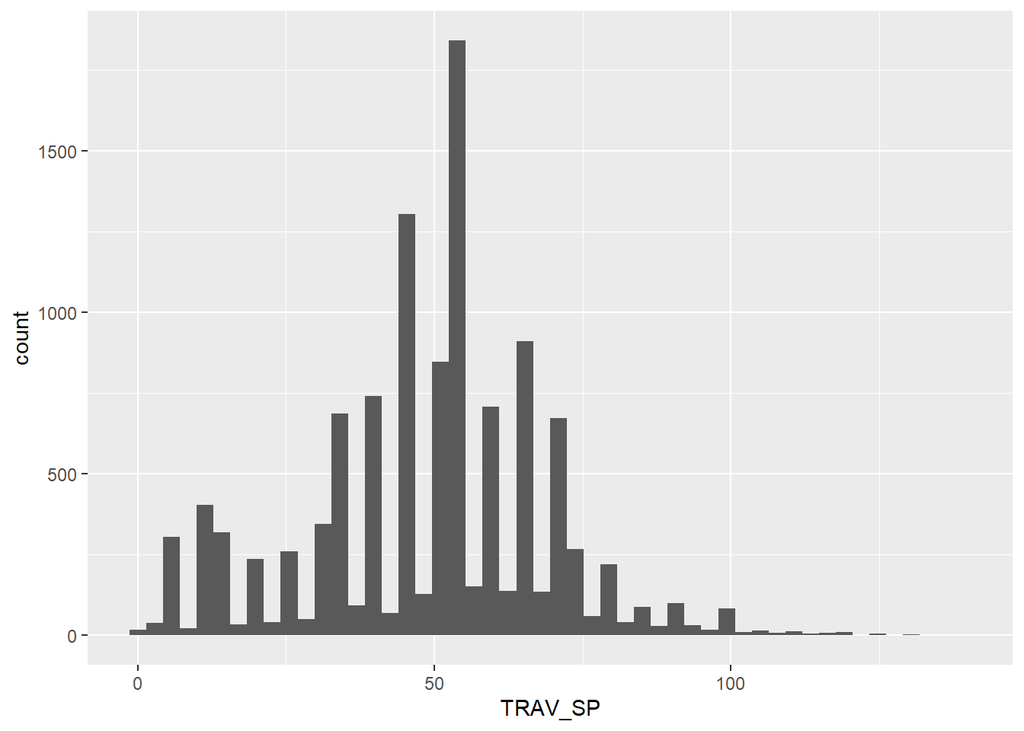

```r
ggplot(c2015,aes(x=TRAV_SP))+
  geom_histogram(bins=50)
```

#5.Plot a histogram of AGE coloring (fill) by SEX.

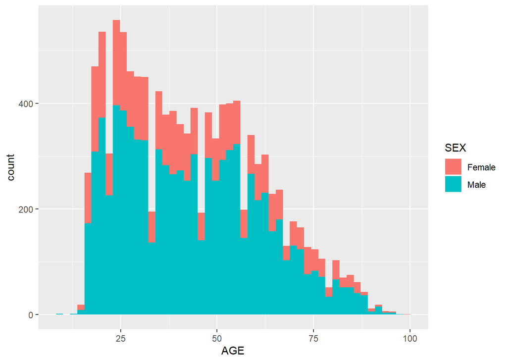

```r
ggplot(c2015,aes(x=AGE,fill=SEX))+
  geom_histogram(bins=50)
```

#6.Using geom_density to plot estimated densities of AGE colored by SEX.

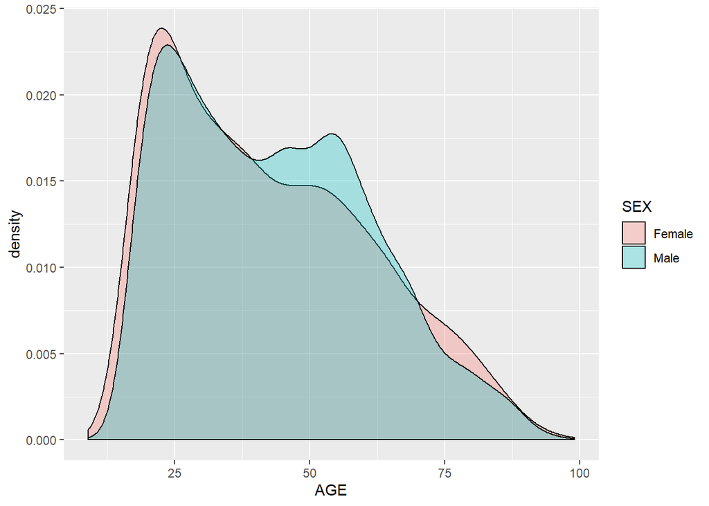

```r
ggplot(c2015,aes(x=AGE,fill=SEX))+
  geom_density(alpha=0.3)
```

#7.Plot estimated densities of TRAV_SP colored by INJ_SEV.

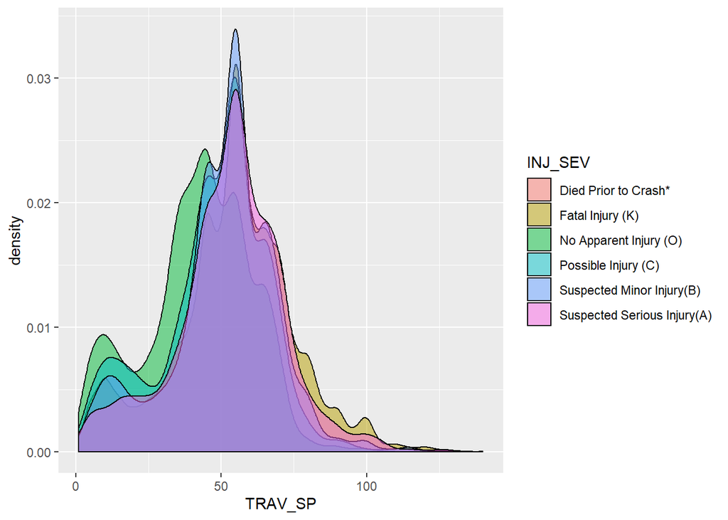

```r
ggplot(c2015,aes(x=TRAV_SP,fill=INJ_SEV))+
  geom_density(alpha=0.5)
```

#8.Plot estimated densities of TRAV_SP seperated (colored) by weekdays and weekends.

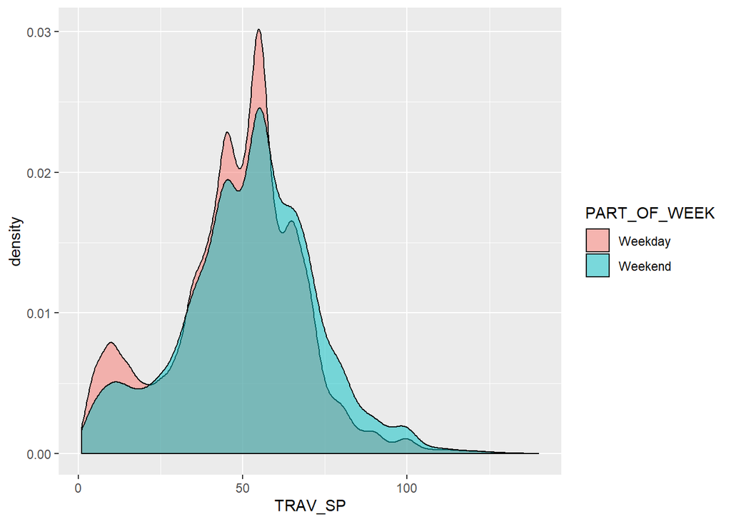

```r
#recode to make weekday and weekend category
c2015<-c2015%>%mutate(PART_OF_WEEK=recode(DAY_WEEK,'Monday'='Weekday','Tuesday'='Weekday','Wednesday'='Weekday','Thursday'='Weekday','Friday'='Weekday','Saturday'='Weekend','Sunday'='Weekend'))
ggplot(c2015,aes(x=TRAV_SP,fill=PART_OF_WEEK))+
  geom_density(alpha=0.5)
```

#9.Implement geom_bar on MONTH. Implement geom_bar on MONTH filled by SEX

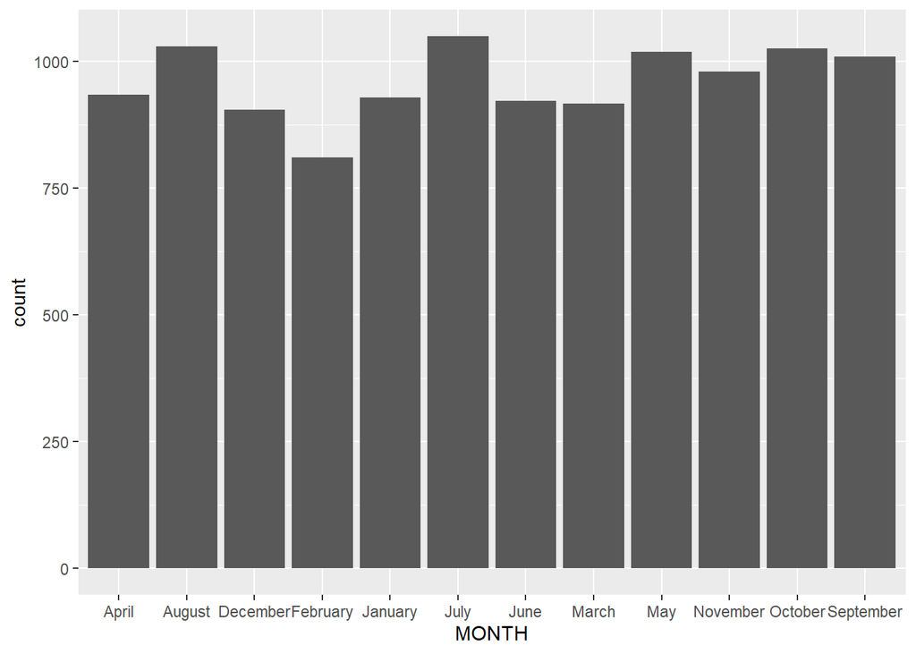

```r
ggplot(c2015,aes(MONTH))+
  geom_bar()
```

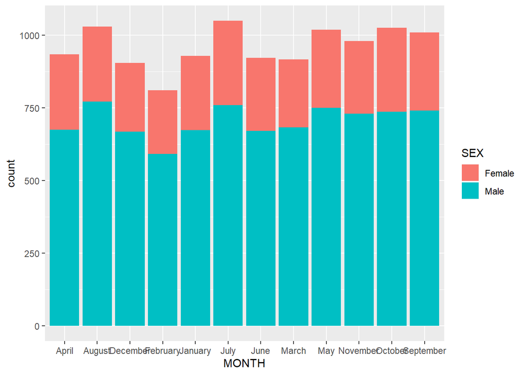

```r
ggplot(c2015,aes(MONTH,fill=SEX))+
  geom_bar()
```

#10.Implement geom_bar on MONTH and SEX with position=‘dodge’

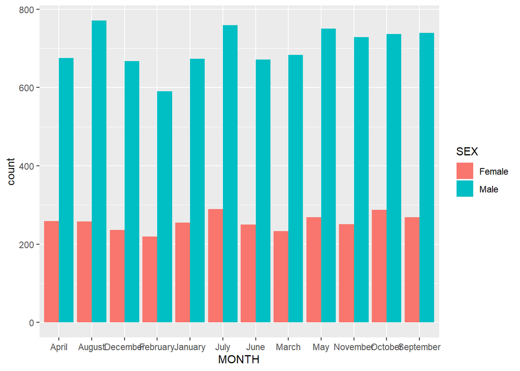

```r
ggplot(c2015,aes(MONTH,fill=SEX))+
  geom_bar(position='dodge')
```

#11.Plot a bar chart of average speeds in months using geom_col

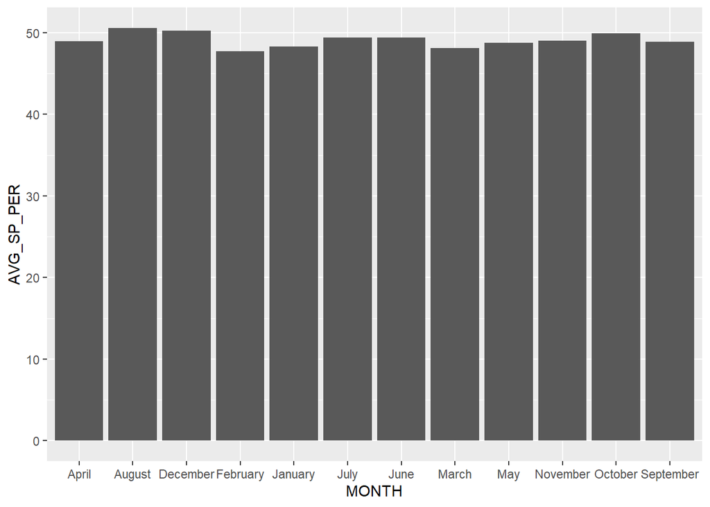

```r
monthdata=c2015%>%group_by(MONTH)%>%mutate(AVG_SP_PER=mean(TRAV_SP)/n())
ggplot(monthdata,aes(MONTH))+
  geom_col(aes(y=AVG_SP_PER))
```

#12.Plot a bar chart of average speeds in months using geom_bar

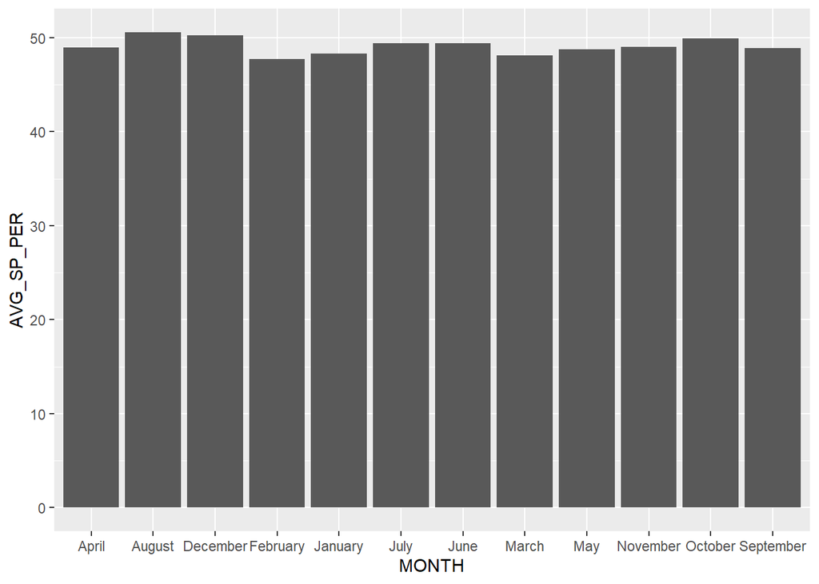

```r
ggplot(monthdata,aes(MONTH))+
  geom_bar(aes(y=AVG_SP_PER),stat='identity')
```

#13.Plot a bar chart of average speeds in months filled by SEX

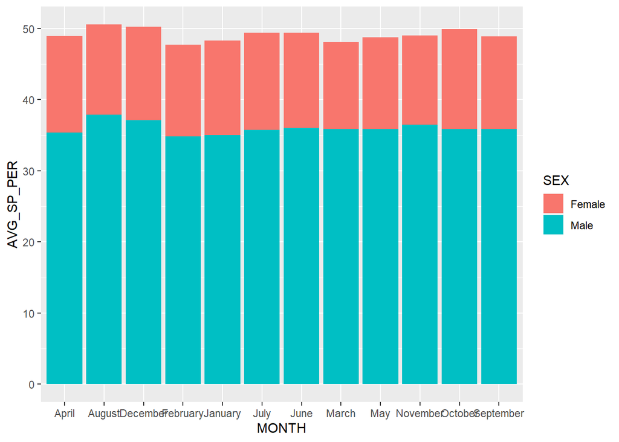

```r
 ggplot(monthdata,aes(MONTH,fill=SEX))+
  geom_col(aes(y=AVG_SP_PER))
```

#14.Plot a bar chart of average speeds in months colored by INJ_SEV

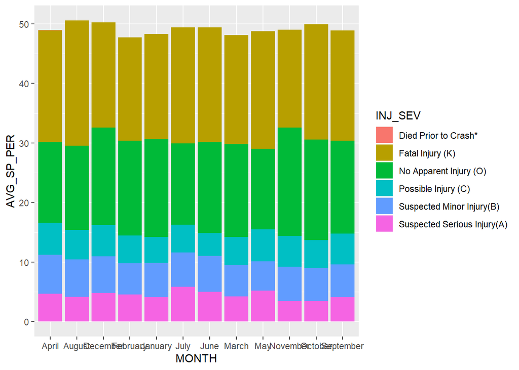

```r
ggplot(monthdata,aes(MONTH,fill=INJ_SEV))+
  geom_col(aes(y=AVG_SP_PER))
```

#15.Refer to this link to have a similar following plot: ##Horizontal axis is for (monthly) average speed ##The vertical axis is for months ##Color by two colors: one for above overall average speed and the other for below the avarage speed ##The speed on the horizontal axis is standardized

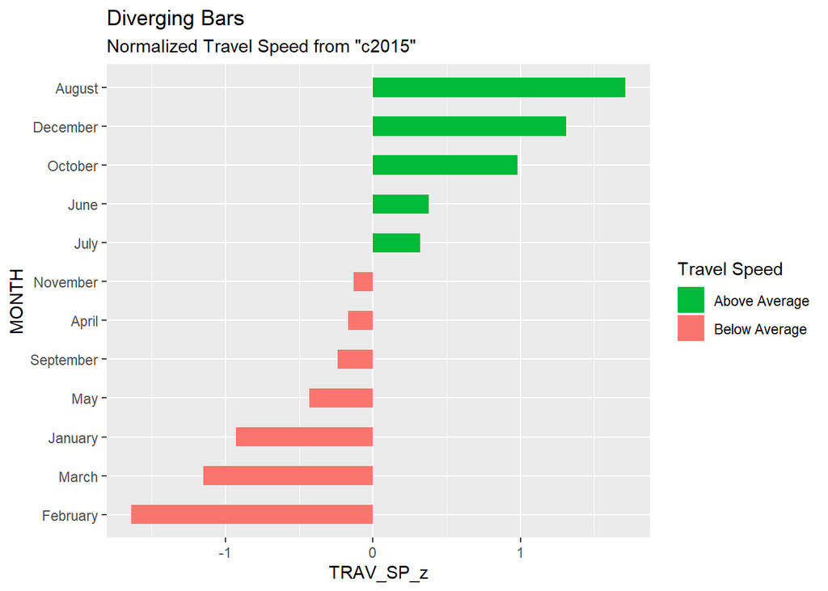

```r
#data prep
months<-c2015%>%group_by(MONTH)%>%summarize(mean=mean(TRAV_SP))%>%arrange(mean)
months$TRAV_SP_z<-round((months$mean-mean(months$mean))/sd(months$mean),2)
months$TRAV_SP_type<-ifelse(months$TRAV_SP_z < 0, 'below','above')
months$MONTH<-factor(months$MONTH,levels=months$MONTH)

#plot
ggplot(months,aes(x=MONTH ,y=TRAV_SP_z ,label=TRAV_SP_z))+
  geom_bar(stat='identity',aes(fill=TRAV_SP_type),width=0.5)+
  scale_fill_manual(name='Travel Speed',
                    labels = c("Above Average", "Below Average"),
                    values = c("above"="#00ba38", "below"="#f8766d"))+
  labs(subtitle = 'Normalized Travel Speed from "c2015"',
       title = 'Diverging Bars')+
  coord_flip()
```

#16.Refer to this link to have a similar following plot: ##Horizontal Axis is for mean speed ##Vertical Axis is for INJ_SEV ##Color by SEX ##he numbers of speed are shown in points.

```r
#data prep
injury<-c2015%>%group_by(INJ_SEV,SEX)%>%summarize(mean=mean(TRAV_SP))%>%ungroup()
injury$MEAN_SP<-round(injury$mean,1)
injury
```

```
## # A tibble: 11 x 4
##    INJ_SEV                     SEX     mean MEAN_SP
##    <chr>                       <chr>  <dbl>   <dbl>
##  1 Died Prior to Crash*        Male    87      87
##  2 Fatal Injury (K)            Female  49.6    49.6
##  3 Fatal Injury (K)            Male    55.3    55.3
##  4 No Apparent Injury (O)      Female  39.8    39.8
##  5 No Apparent Injury (O)      Male    42.9    42.9
##  6 Possible Injury (C)         Female  44.4    44.4
##  7 Possible Injury (C)         Male    49.0    49
##  8 Suspected Minor Injury(B)   Female  48.1    48.1
##  9 Suspected Minor Injury(B)   Male    51.9    51.9
## 10 Suspected Serious Injury(A) Female  50.7    50.7
## 11 Suspected Serious Injury(A) Male    53.9    53.9
```

[figure not shown]

```r
#plot
ggplot(injury, aes(x=INJ_SEV, y=MEAN_SP, label=MEAN_SP)) +
  geom_point(stat='identity', aes(col=SEX), size=7,alpha=0.7)  +
  scale_color_manual(name="Travel Speed",
                     labels = c("Male", "Female"),
                     values = c("Male"="#00ba38", "Female"="#f8766d")) +
  geom_text(color="white", size=1.8) +
  labs(title="Dot Plot",
       subtitle="Mean Travel Speed from 'c2015': Dotplot") +
  ylim(39,87) +
  coord_flip()
```

```r
######TRY TO FIX THIS BETTER TO MAKE IT DIVERGE!!!!!!!!!!!
```

#17.Refer to this link to have a similar following plot: ##Horizontal Axis is for speed ##Vertical Axis is for DAY ##Color by SEX ##The should be a invisible vertical line seperating the two sexes.

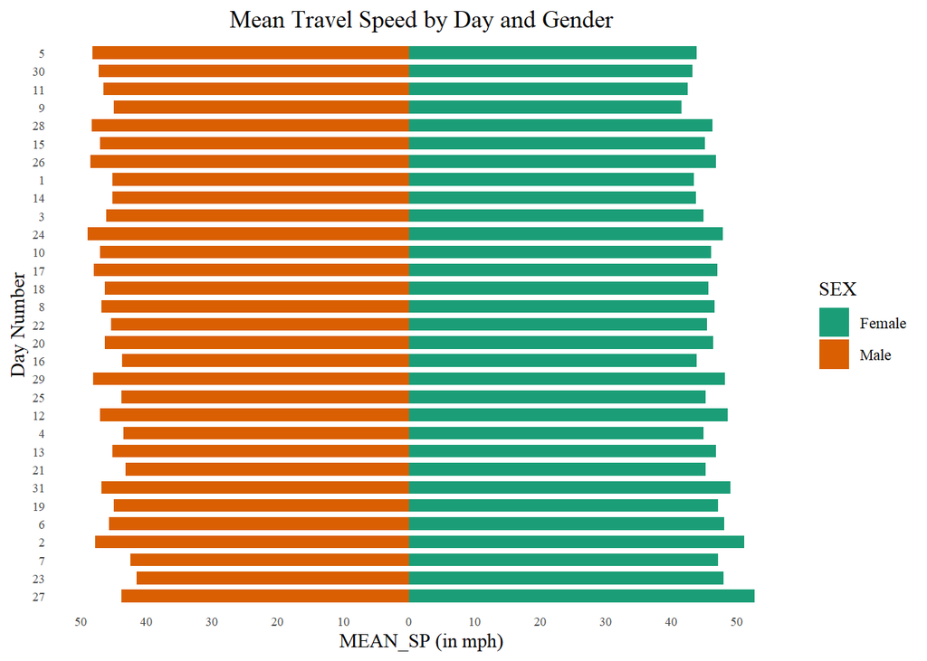

```r
#data/plot prep
library(ggthemes)
days<-c2015%>%group_by(DAY,SEX)%>%summarize(mean=mean(TRAV_SP))%>%arrange(mean)%>%ungroup()
days$MEAN_SP<-round(days$mean,2)
days$MEAN_SP[days$SEX=='Male']=-days$MEAN_SP
brks <- seq(-50,50, 10)
lbls <- paste0(as.character(c(seq(50, 0,-10), seq(10, 50, 10)), "mph"))

#plot
ggplot(days,aes(x=reorder(DAY,-MEAN_SP),y=MEAN_SP,fill=SEX))+
  geom_bar(stat='identity',width=0.7)+
  scale_y_continuous(breaks=brks,
                     labels=lbls)+
  coord_flip()+
  labs(title = 'Mean Travel Speed by Day and Gender')+
  theme_tufte()+
  theme(plot.title=element_text(hjust=0.5),
        axis.ticks=element_blank(),
        axis.text=element_text(size=7))+
  scale_fill_brewer(palette='Dark2')+
  xlab('Day Number')+
  ylab('MEAN_SP (in mph)')
```

#18-20. Generate three other interesting graphs from the dataset.

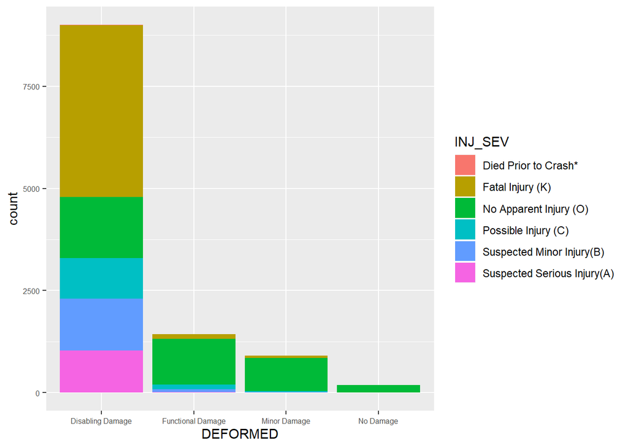

```r
#Question 18

ggplot(c2015,aes(x=DEFORMED,fill=INJ_SEV))+
  geom_bar()+
  theme(axis.text=element_text(size=6))
```

```r
#This graph shows the count for each type of damage of the car colored by the severity of the injury of the person. When more damage is done to the car, the higher the chance of a more serious injury to the person.
```

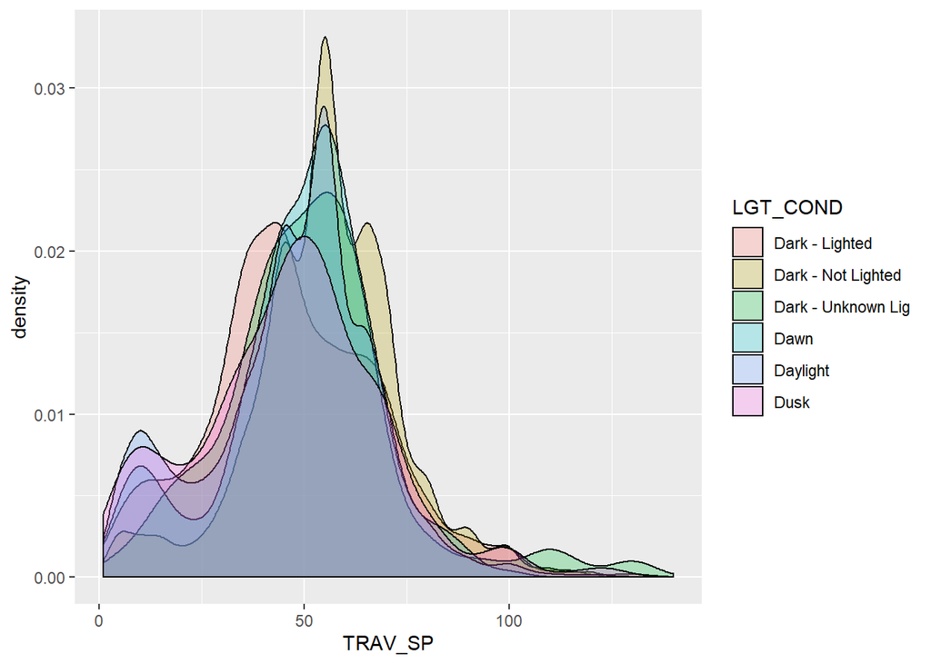

```r
#Question 19

ggplot(c2015,aes(x=TRAV_SP,fill=LGT_COND))+
  geom_density(alpha=0.25)
```

```r
#This density graph shows the travel speed of drivers in accidents colored by the lighting condition at the time of the accident. It appears that when drivers tended to drive the fastest when the road was dark or not lighted, which is surprising because people are usually more  comfortable when the road is lit.
```

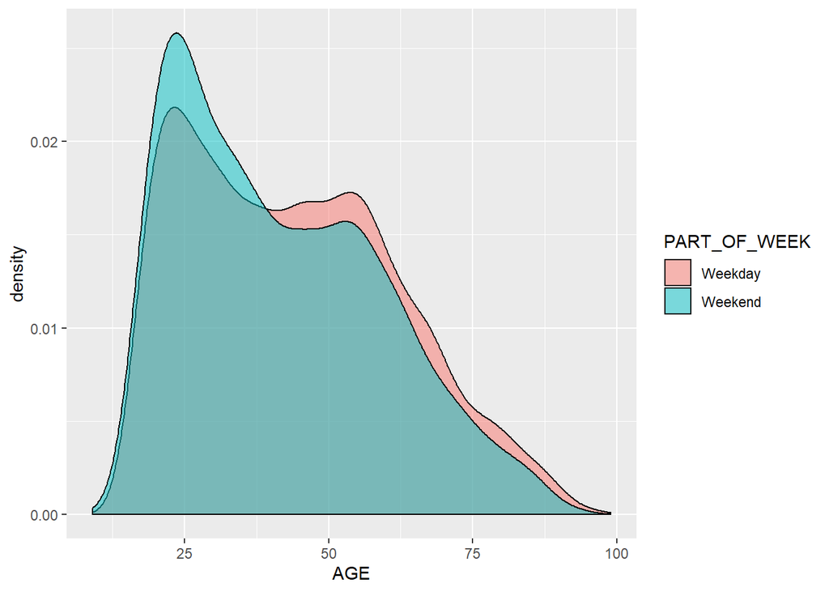

```r
#Question 20
ggplot(c2015,aes(AGE,fill=PART_OF_WEEK))+
  geom_density(alpha=0.5)
```

```r
#This graph shows the distribution of ages of drivers in accidents based on whether the accident occurred on a weekday or weekend. This shows that younger drivers occurred in accidents on weekends, which makes sense as younger people tend to go out more on weekends.
```